# Penguins

Sachi Srivastava 2024-09-13

## Data

The Palmer Penguins dataset was made available by Dr. Kristen Gorman and the Palmer Station, Antarctica LTER (Long Term Ecological Research) Network. The package includes 2 datasets, one raw, and one modified, to aid in data visualization. More information is available at this link: https://allisonhorst.github.io/palmerpenguins/

Let’s install and load the Palmer Penguins package.

```r
library(palmerpenguins)
library(tidyverse)
view(penguins)
```

## Single trait distribution

Now we are ready to visualize the distribution of a single trait. Let’s look at the density distribution of bill sizes among the three species surveyed at Palmer Station.

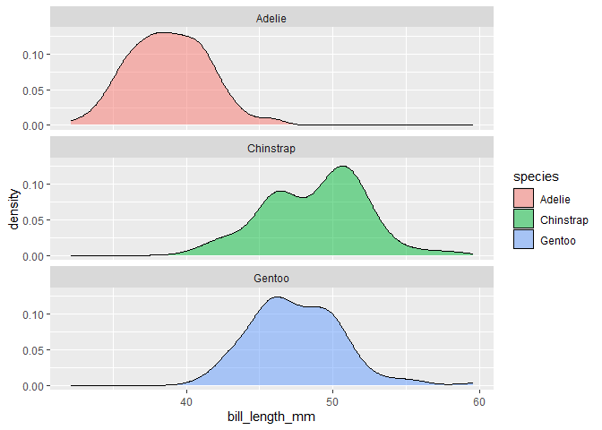

```r
ggplot(penguins) +
  geom_density(mapping = aes(bill_length_mm, fill = species), alpha = 0.5) +
    facet_wrap(~species, nrow=3)
```

Let’s also see how these traits overlap.

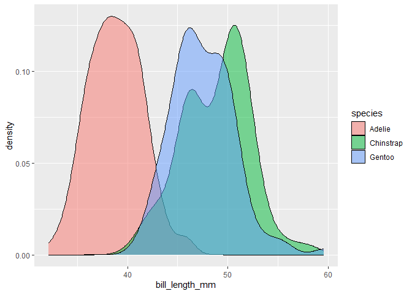

```r
ggplot(penguins) +
  geom_density(mapping = aes(bill_length_mm, fill = species), alpha = 0.5)
```

## Sexual dimorphism

Now, let’s look at the relationship between multiple traits. Let’s find out if any of the surveyed traits are sexually dimorphic.

Let’s look at bill length and depth

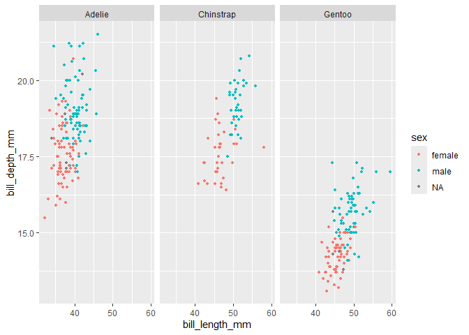

```r
  ggplot(penguins) +
  geom_point(mapping = aes(x = bill_length_mm, y=bill_depth_mm, color=sex), size = 1) +
  facet_wrap(~species)
```

It appears that Chinstrap penguins have the greatest degree of sexual dimorphism for these traits.

Now, let’s look at body mass and flipper size.

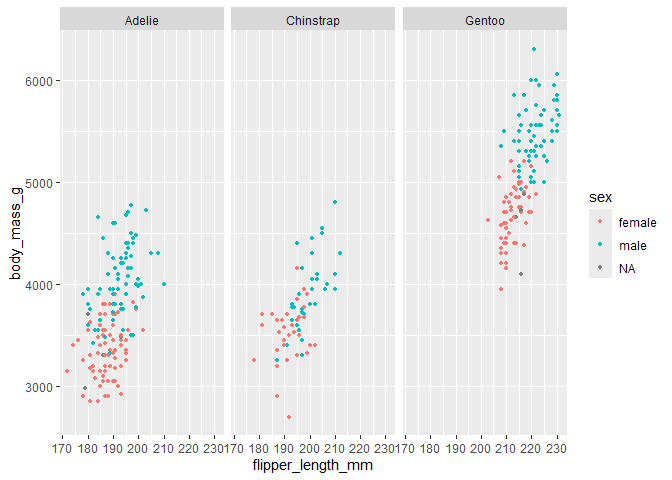

```r
 ggplot(penguins) +
  geom_point(mapping = aes(x = flipper_length_mm, y = body_mass_g, color=sex), size = 1) +
  facet_wrap(~species)
```

It looks like the degree of sexual dimorphism for these traits is highest in Gentoo penguins.

Let’s simplify how we are visualizing the data, using the example of flipper length.

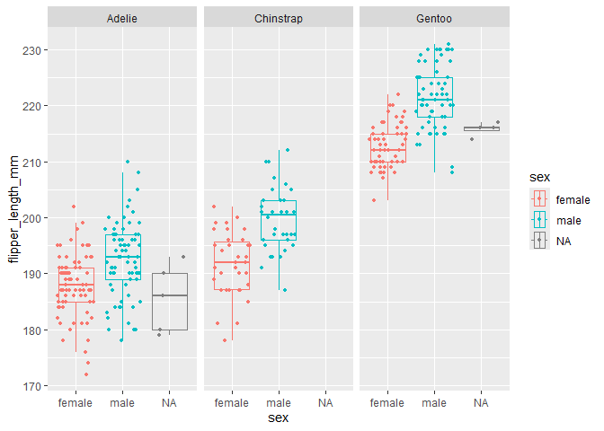

```r
penguins %>%
  ggplot(mapping = aes(x=flipper_length_mm, y=sex, color=sex)) +
  geom_boxplot(outlier.alpha = 0, alpha=0) +
  geom_jitter(width = 0, size=1) +
  coord_flip() +
  facet_wrap(~species)
```

## Multiple Traits

Finally, let’s look at the distribution of multiple traits in the surveyed penguins.Let’s look at body mass and flipper size by species.

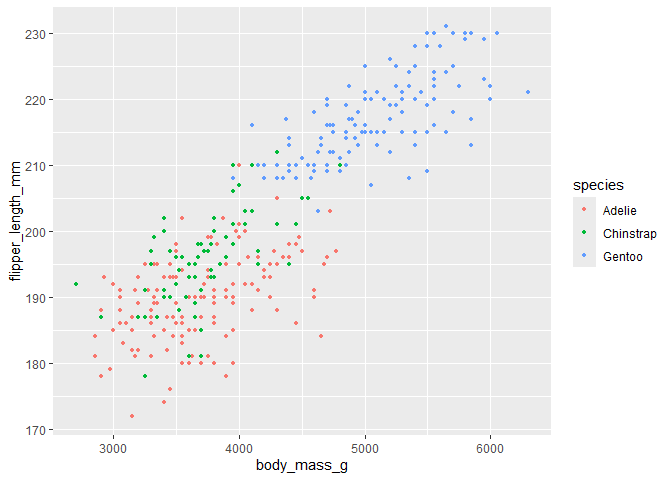

```r
 ggplot(penguins) +
  geom_point(mapping = aes(x = body_mass_g, y = flipper_length_mm, color=species), size = 1)
```

We are done exploring these data for now! What other relationships can you find between the variables in this data set?